# Homework 2: loops and functions

# Homework 2

Answer the questions below. Several of the problems below could be solved by using an existing R package, but since the goal of this assignment is to learn more about how R functions and loops work, **I’m going to ask you not to load any additional R packages other than the ones that are explicitly mentioned below.

Note that for the last question you can answer **either** A or B. You don’t need to answer both questions unless you just want the extra practice.

## Question 1

Write a function that takes a character vector and returns the modal (most common) value of that vector. You can use `testvec` below to test your code:

```r
testvec<-c("a","b","b", "c","d","d","d","e" ,"f")
```

### Q1. Answer

An easy option using `table` with `which.max`, and then returning the **name** of the most common element:

```r
testvec<-c("a","b","b", "c","d","d","d","e" ,"f")

modalValue<-function(x){
  freq<-table(x)
  most_common<-names(freq)[which.max(freq)]
  return(most_common)
}

modalValue(testvec)
```

```
[1] "d"
```

Here’s a version that relies on a single R loop (note that this is wildly inefficient! It’s just here for illustration.)

```r
testvec<-c("a","b","b", "c","d","d","d","e" ,"f")

x<-testvec


modalValueLoop <- function(x) {
  freqs <- c()
  current_max_value <- 0
  for (i in x) {
    # manually creating a frequency table as a named vector:

    if (i %in% names(freqs)) {
      freqs[i] <- freqs[i] + 1
    } else{
      freqs[i] <- 1
    }

    # check to see if this is a new modal value
    if (freqs[i] > current_max_value) {
      current_max_value <- freqs[i]
    }

  }
  return(names(current_max_value)[1])

}
# empty vector to hold results




modalValueLoop(testvec)
```

```
[1] "d"
```

### Question 2

Consider the function you created in question 1. In some cases, a vector might have more than one modal value. For instance, “b” and “d” both occur twice in the vector below:

```r
# Vector with two modes: b and d
testvec<-c("a","b","b", "c","d","d","e" ,"f")
```

Modify the function you created in question one to handle cases where there is more than one modal value. Your function should allow you to choose between an option that always returns a single value (arbitrarily selecting one mode if there are ties) or an option that returns a vector with all of the modal values regardless of the number.

### Q2. Answer

Instead of `which.max` (which ignores ties) I can use something like `x[which(x==max(x))]`, which would return any elements in `x` that are equal to the maximum value.

Then, I just need to add an `if` statement to my function that will only take a single element if `allow_ties` is `FALSE`, or does nothing if `allow_ties` is `TRUE`:

```r
testvec<-c("a","b","b", "c","d","d","e" ,"f")

modalValueMulti <- function(x, allow_ties = FALSE) {
  freq <- table(x)
  allmodes <- names(freq)[which(freq == max(freq))]
  if (allow_ties == FALSE) {
    allmodes <- allmodes[1]
  }
  return(allmodes)
}

modalValueMulti(testvec, allow_ties = T)
```

```
[1] "b" "d"
```

## Question 3

The [electoral](https://cran.r-project.org/web/packages/electoral/index.html) package includes a function for calculating the effective number of political parties from a vector of seats or votes.

Take a look at the source code for electoral’s version of the `enp` function by running the code below:

```r
#install.packages("electoral")
library(electoral)

View(enp)
```

Explain what the line below does in your own words (you don’t need to explain the difference between “Laakso-Taagepera” vs. “Golosov”, just say what this check does and how it might be triggered):

```
if (!method %in% c("Laakso-Taagepera", "Golosov")) {
    stop("Not a valid method")
    }
```

If you’re curious “Laakso-Taagepera” and “Golosov” are the names of political scientists. Laakso and Taagepera wrote the original [1979 paper](https://journals-sagepub-com.proxy-um.researchport.umd.edu/doi/10.1177/001041407901200101) that proposed the ENP measure we’ve used in class. Grigorii Golosov wrote a [2010 paper](https://www-tandfonline-com.proxy-um.researchport.umd.edu/doi/abs/10.1080/23745118.2014.974342) that suggested an alternative formula that corrects some measurement weirdness that happens when there’s a single dominant party.

### Q3. Answer

The line checks whether the `method` argument is set to equal to either “Laakso-Taagepera” or “Golosov”. If not, it throws an error message.

## Question 4

In R, missing data is typically represented as an `NA` value. The `is.na()` function will return `TRUE` for each `NA` in a vector and `FALSE` for everything else.

Write a loop that **creates a vector** called `missing_values` that contains the total number of missing observations for each row of the 2024 Chapel Hill Expert Survey data set. The code to load that data set is included below:

```r
ches<-readr::read_csv('https://github.com/chesdata/chesdata.github.io/releases/download/ches-europe/CHES_2024_final_v2.csv')
```

Hint: using `sum` on a boolean (`TRUE/FALSE`) vector will count give you the number of `TRUE` values in that vector.

### Q4. Answer

This one is reasonably straightforward. We just need to loop through each row of `ches` and sum up the results of running `is.na` on each row:

```r
# empty numeric vector with the same length as the number of rows in my data frame
missing_values<-numeric(length = nrow(ches))


for(i in 1:nrow(ches)){
  missing_values[i]<-sum(is.na(ches[i, ]))

}

missing_values
```

```
  [1] 0 0 0 0 0 0 1 0 0 1 0 0 0 0 0 0 0 0 0 0 0 1 0 0 0 0 0 0 0 0 0 0 1 1 1 1 1
 [38] 2 2 3 3 3 0 0 1 0 0 0 1 0 0 0 0 0 0 1 0 0 0 0 0 0 0 0 0 0 0 0 0 0 0 0 0 0
 [75] 0 0 3 0 0 0 0 0 0 1 0 0 0 0 0 1 0 0 0 0 2 0 0 0 0 1 1 1 1 2 1 1 0 0 0 0 0
[112] 0 0 0 0 0 0 0 0 0 0 0 0 0 0 0 0 0 0 9 0 0 0 0 0 0 0 0 1 0 0 0 0 0 0 0 1 0
[149] 0 0 0 0 0 0 0 0 0 0 0 0 0 0 0 0 0 0 0 3 0 0 0 0 0 0 0 0 0 1 0 1 0 0 0 0 0
[186] 0 0 0 0 0 0 0 0 1 0 0 0 0 0 0 0 0 0 0 0 0 0 0 0 0 1 0 0 0 0 0 0 0 0 0 0 0
[223] 0 0 0 0 0 0 0 0 0 0 0 0 0 0 4 4 4 4 4 4 4 4 4 4 4 4 4 4 4 4 4 4 4 4 4 4 6
[260] 6 5 5 6 6 2 2 2 3 2 3 2 4 4 4 4 4 4 4 6
```

Note: this is another scenario where there’s a much faster built-in R function that runs the loop in another language. The `rowSums` and `colSums` functions will sum the values in the rows or columns of a matrix, and we can apply `is.na` to the entire data frame in one fell swoop.

```r
# empty numeric vector with the same length as the number of rows in my data frame

rowSums(is.na(ches))
```

```
  [1] 0 0 0 0 0 0 1 0 0 1 0 0 0 0 0 0 0 0 0 0 0 1 0 0 0 0 0 0 0 0 0 0 1 1 1 1 1
 [38] 2 2 3 3 3 0 0 1 0 0 0 1 0 0 0 0 0 0 1 0 0 0 0 0 0 0 0 0 0 0 0 0 0 0 0 0 0
 [75] 0 0 3 0 0 0 0 0 0 1 0 0 0 0 0 1 0 0 0 0 2 0 0 0 0 1 1 1 1 2 1 1 0 0 0 0 0
[112] 0 0 0 0 0 0 0 0 0 0 0 0 0 0 0 0 0 0 9 0 0 0 0 0 0 0 0 1 0 0 0 0 0 0 0 1 0
[149] 0 0 0 0 0 0 0 0 0 0 0 0 0 0 0 0 0 0 0 3 0 0 0 0 0 0 0 0 0 1 0 1 0 0 0 0 0
[186] 0 0 0 0 0 0 0 0 1 0 0 0 0 0 0 0 0 0 0 0 0 0 0 0 0 1 0 0 0 0 0 0 0 0 0 0 0
[223] 0 0 0 0 0 0 0 0 0 0 0 0 0 0 4 4 4 4 4 4 4 4 4 4 4 4 4 4 4 4 4 4 4 4 4 4 6
[260] 6 5 5 6 6 2 2 2 3 2 3 2 4 4 4 4 4 4 4 6
```

## Question 5

You can answer either Question A OR Question B. I will consider giving credit for answers that don’t quite work if you provide a detailed description of what you’re trying to accomplish and where you got stuck.

### Question 5A

In class work 2, you created a function to retrieve federal poverty levels from the HHS website. Now imagine a scenario where you’re asked to write some code to automatically identify applicants to a program who are below the poverty level for their household size.

Write a function that takes a data frame with values for household size, income and year and returns a vector of `TRUE/FALSE` values that indicates whether each row is below the poverty level.

Your function should also:

- Avoid “hard-coding” specific values, so that it can run in 2026 without any additional modifications.
- Avoid sending redundant requests to HHS. In other words: if there are 20 households of size 3 in year 2025, you should only `fromJSON` once and then just use that single response for all 20 observations rather than running `fromJSON` 20 times.

To make this more concrete, I’ve created some (unrealistic) simultated household data that you can import by running the code below:

```r
url<-'https://raw.githubusercontent.com/Neilblund/GVPT628Fall2025/refs/heads/main/Data/fake_households.csv'
households<-readr::read_csv(url)
```

#### Question 5A. Answer

**Option 1**

Here’s one way to do this. The function below works by creating the request URL for every row in the data, then using `unique` to get a list of unique URLs. Then, we can loop over the list of unique URLs (instead of looping over all rows in the data frame). Next, we assign the result to all rows in the household data that have a URL that matches the `i`-th URL in our loop, and finally, we check to see whether the income in each row is greater than the relevant poverty threshold.

```r
checkFPL <- function(years,
                       household_sizes,
                       incomes,
                       states = 'US') {
    # creating an empty vector that will hold the threshold data
    thresholds<-numeric()
    hh_data <- data.frame(
      year = years,
      household_size = household_sizes,
      income = incomes,
      poverty_threshold = NA,
      poverty_indicator = NA
    )
    base_url <- 'https://aspe.hhs.gov/topics/poverty-economic-mobility/poverty-guidelines/api'
    hh_data$completed_url<-paste0(base_url, "/", years, '/', states, '/', household_sizes)
    unique_urls<-unique(hh_data$completed_url)
    # loop through the unique URLs and retrieve data
    for (i in unique_urls) {
        cat("Sending a request to", i, "\n")
        response <- jsonlite::fromJSON(i)
        # adding a named element to the numeric vector
        thresholds[i] <- as.numeric(response$data$income)

    }
    # using name based indexing to match a threshold to a URL
    hh_data$poverty_threshold <- unname(thresholds[hh_data$completed_url])

    # in each row, just check to see whether the household income is above the
    # poverty threshold in that row
    hh_data$poverty_indicator<-hh_data$income < hh_data$poverty_threshold

    return(hh_data)
}

household_income_data<-checkFPL(years = households$year,
                                household_sizes = households$household_size,
                                incomes = households$income)
```

```
Sending a request to https://aspe.hhs.gov/topics/poverty-economic-mobility/poverty-guidelines/api/2025/US/10
Sending a request to https://aspe.hhs.gov/topics/poverty-economic-mobility/poverty-guidelines/api/2025/US/4
Sending a request to https://aspe.hhs.gov/topics/poverty-economic-mobility/poverty-guidelines/api/2025/US/3
Sending a request to https://aspe.hhs.gov/topics/poverty-economic-mobility/poverty-guidelines/api/2025/US/9
Sending a request to https://aspe.hhs.gov/topics/poverty-economic-mobility/poverty-guidelines/api/2025/US/2
Sending a request to https://aspe.hhs.gov/topics/poverty-economic-mobility/poverty-guidelines/api/2025/US/1
Sending a request to https://aspe.hhs.gov/topics/poverty-economic-mobility/poverty-guidelines/api/2025/US/6
Sending a request to https://aspe.hhs.gov/topics/poverty-economic-mobility/poverty-guidelines/api/2025/US/8
Sending a request to https://aspe.hhs.gov/topics/poverty-economic-mobility/poverty-guidelines/api/2025/US/7
Sending a request to https://aspe.hhs.gov/topics/poverty-economic-mobility/poverty-guidelines/api/2025/US/5
```

```r
household_income_data|>
  head(n=10)
```

| year | household_size | income | poverty_threshold | poverty_indicator | completed_url |
| --- | --- | --- | --- | --- | --- |
| 2025 | 10 | 45450.63 | 65150 | TRUE | https://aspe.hhs.gov/topics/poverty-economic-mobility/poverty-guidelines/api/2025/US/10 |
| 2025 | 4 | 37671.99 | 32150 | FALSE | https://aspe.hhs.gov/topics/poverty-economic-mobility/poverty-guidelines/api/2025/US/4 |
| 2025 | 3 | 29375.12 | 26650 | FALSE | https://aspe.hhs.gov/topics/poverty-economic-mobility/poverty-guidelines/api/2025/US/3 |
| 2025 | 9 | 38952.79 | 59650 | TRUE | https://aspe.hhs.gov/topics/poverty-economic-mobility/poverty-guidelines/api/2025/US/9 |
| 2025 | 2 | 30888.64 | 21150 | FALSE | https://aspe.hhs.gov/topics/poverty-economic-mobility/poverty-guidelines/api/2025/US/2 |
| 2025 | 3 | 43038.13 | 26650 | FALSE | https://aspe.hhs.gov/topics/poverty-economic-mobility/poverty-guidelines/api/2025/US/3 |
| 2025 | 1 | 36587.79 | 15650 | FALSE | https://aspe.hhs.gov/topics/poverty-economic-mobility/poverty-guidelines/api/2025/US/1 |
| 2025 | 3 | 26272.02 | 26650 | TRUE | https://aspe.hhs.gov/topics/poverty-economic-mobility/poverty-guidelines/api/2025/US/3 |
| 2025 | 10 | 34232.50 | 65150 | TRUE | https://aspe.hhs.gov/topics/poverty-economic-mobility/poverty-guidelines/api/2025/US/10 |
| 2025 | 6 | 33102.30 | 43150 | TRUE | https://aspe.hhs.gov/topics/poverty-economic-mobility/poverty-guidelines/api/2025/US/6 |

**Option 2**

Here’s a more advanced method for setting this up using a kind of structure called a closure. In this setup, the `fplChecker` function returns another function that performs most of the work of checking the poverty levels.

The inner function, called `checkFPL` mostly works the same way as the function in option 1, but you’ll notice there’s a line inside the loop that retrieves data from HHS that looks like this:

`thresholds[i] <<- as.numeric(response$data$income)`

The `<<-` operator is called a “super assignment” operator. This operator overrides R’s default lexical scoping to create/update a variable in the current function’s parent environment. In other words, this inner function actually updates the `thresholds` variable that is created in the first line of `fplChecker`.

This setup allows the `thresholds` variable to persist across multiple function calls. This is useful because it means we can run the same function on a new data set and it will only send API requests if the `thresholds` variable doesn’t already contain the information we’re looking for.

```r
fplChecker <- function() {
  thresholds<-numeric() # thresholds variable created in the outer function!
  checkFPL <- function(years,
                       household_sizes,
                       incomes,
                       states = 'US') {

    hh_data <- data.frame(
      year = years,
      household_size = household_sizes,
      income = incomes,
      poverty_threshold = NA,
      poverty_indicator = NA
    )

    base_url <- 'https://aspe.hhs.gov/topics/poverty-economic-mobility/poverty-guidelines/api'

    hh_data$completed_url<-paste0(base_url, "/", years, '/', states, '/', household_sizes)
    unique_urls<-unique(hh_data$completed_url)


    # loop through the unique URLs and retrieve data
    for (i in unique_urls) {
      if (!i %in% names(thresholds)) {
        cat("Sending a request to", i, "\n")
        response <- jsonlite::fromJSON(i)
        thresholds[i] <<- as.numeric(response$data$income) # <<- updates in the outer function
      }

    }
    hh_data$poverty_threshold <- unname(thresholds[hh_data$completed_url])

    # in each row, just check to see whether the household income is above the
    # poverty threshold in that row
    hh_data$poverty_indicator<-hh_data$income < hh_data$poverty_threshold

    return(hh_data)
  }
}

# create a new fplChecker function - note that this returns another function we're called "fpl"
fpl<-fplChecker()

# Use the fpl() function
household_income_data <- fpl(
  years = households$year,
  household_sizes = households$household_size,
  incomes = households$income
)
```

```
Sending a request to https://aspe.hhs.gov/topics/poverty-economic-mobility/poverty-guidelines/api/2025/US/10
Sending a request to https://aspe.hhs.gov/topics/poverty-economic-mobility/poverty-guidelines/api/2025/US/4
Sending a request to https://aspe.hhs.gov/topics/poverty-economic-mobility/poverty-guidelines/api/2025/US/3
Sending a request to https://aspe.hhs.gov/topics/poverty-economic-mobility/poverty-guidelines/api/2025/US/9
Sending a request to https://aspe.hhs.gov/topics/poverty-economic-mobility/poverty-guidelines/api/2025/US/2
Sending a request to https://aspe.hhs.gov/topics/poverty-economic-mobility/poverty-guidelines/api/2025/US/1
Sending a request to https://aspe.hhs.gov/topics/poverty-economic-mobility/poverty-guidelines/api/2025/US/6
Sending a request to https://aspe.hhs.gov/topics/poverty-economic-mobility/poverty-guidelines/api/2025/US/8
Sending a request to https://aspe.hhs.gov/topics/poverty-economic-mobility/poverty-guidelines/api/2025/US/7
Sending a request to https://aspe.hhs.gov/topics/poverty-economic-mobility/poverty-guidelines/api/2025/US/5
```

If we run this same bit of code a second time, you’ll notice that it returns the same data, but it doesn’t send any new requests:

```r
household_income_data <- fpl(
  years = households$year,
  household_sizes = households$household_size,
  incomes = households$income
)
```

### Question 5B

In class work 2, we used the jackknife method to calculate the standard error for a median. Bootstrapping is a closely related method for calculating the standard error of an estimator with an unknown sampling distribution that relies on randomly sampling from our original data with replacement to create multiple simulated data sets.

Resampling with replacement means that we could sample some observations more than once. Think of it like drawing a card at random from a deck, recording the suit and number and then placing that card back into the deck and re-shuffling. Repeating the process of drawing, replacing, and re-shuffling 52 times to create a new “simulated” deck of cards. In some cases, you might get a draw the queen of hearts three times, and in some cases you might draw no queens at all, so your simulated decks will all be slightly different from one another.

In bootstrapping, re-sampling with replacement ensures that we get simulated data sets with a small amount of variability. Moreover, the variation in our bootstrapped replicates will be proportional to the amount of variation in our sample itself and, by extension, they’ll simulate the sampling variability in the target population.

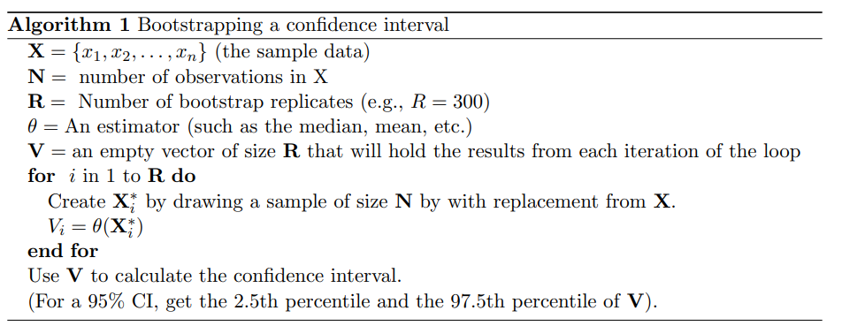

You can re-sample a vector with replacement by using the `sample` function along with a couple of optional commands. Here’s an example of resampling “X” with replacement:

```r
x<-c(1, 2, 3, 4, 5, 6)
x_resampled<-sample(x, size=length(x), replace=T)
x_resampled
```

[output not shown]

You can calculate the nth percentile of a vector using the `quantile` function:

```r
# a vector of values:
v <- c(.1, .2, .5, .6, .7,.9)

# the 2.5th and 97.5th percentiles of v:
quantile(v, c(.025, .975))
```

```
  2.5%  97.5%
0.1125 0.8750
```

Calculate a bootstrapped 95% confidence interval for the median of the `people_vs_elite` measure from the `party_data` data frame created by this code:

```r
ches_experts<-readr::read_csv('https://github.com/chesdata/chesdata.github.io/releases/download/ches-europe/CHES2019_experts.csv')


party_data<-subset(ches_experts, party_id =='2114' & !is.na(people_vs_elite),
                   select=c(id, party_name, people_vs_elite))

median(party_data$people_vs_elite)
```

```
[1] 7.5
```

#### Q5B. Answer

One function that we didn’t discuss here is `set.seed`. This function controls the initial state for R’s random number generating processes. When we’re dealing with functions like `sample`, or `rnorm` that generate random data, the `set.seed` function will ensure that these “random” processes still generate replicable data.

```r
set.seed(999)

n <- length(x)
v <- numeric(length = n)
r <- 300
for(i in 1:r){
  x_boot<-sample(x, size=n, replace=T)
  v[i] <- median(x_boot, na.rm=T)
  }

  v_ci = quantile(v, c(.025,.975))



v_ci
```

```
 2.5% 97.5%
  1.5   5.5
```

Once we’ve got that nailed down, its reasonably easy to make something like this in to a reuseable function. We can actually pass functions as arguments to other functions, so we can make a generic bootstrapping function that will perform this operation for statistics other than the median:

```r
# "theta" here would be the name of any R function that takes a numeric vector
# and outputs a single numeric value.
bootFunction<-function(x,theta, r = 1000, ci = .95, seed=NULL){
  if(!is.null(seed)){
    set.seed(999)
  }
  n<-length(x)
  v<-numeric(length = n)
  for(i in 1:r){
    x_boot<-sample(x, size=n, replace=T)
    v[i] <- theta(x_boot)
  }

  lb<-(1 - ci)/2
  ub<-1 - lb
  v_ci = quantile(v, c(lb, ub))
  return(list("sample_theta" =theta(x), "ci"= v_ci))
}


# example of getting a 95% ci around the interquartile range from a sample:
bootFunction(party_data$people_vs_elite,
             r = 300,
             theta = IQR,
             seed = 999)
```

```
$sample_theta
[1] 3

$ci
 2.5% 97.5%
 1.75  4.00
```

There are several R packages that provide more flexible (and potentially much faster) versions of the bootstrap function above. The [boot](https://cran.r-project.org/web/packages/boot/index.html) package, and the tidyverse friendly [rsample](https://rsample.tidymodels.org/index.html) are both worth considering for more practical applications.